# PocketGems_DataChallenge

Danniel_Winarto

August 6, 2017

## Table of Content :

### 1. Approach

### 2. Setup, 1st stage Data Cleaning

### 3. Missing Value inspection

### 4. Exploratory

### 5. 2nd stage Data Cleaning and Building Model

### 6. Thoughts about Session table

### 7. Answer to questions

### 8. Crossvalidation of the model

## 1. Approach

```
read the dataset
extract the device type from the column hw_ver
find of each table the missing values using library(VIM)
exploratory analysis:
    how many registered user actually ever played the game
    how many registered user actually spend money on the game
    comparing the existing user tracked in session table against list of user in user table
    aggregated money spent by the user, also the frequency of purchase
    etc
Data wrangling & modelling:
    joining user table & IAP table
    for each purchase, find how many days and weeks since registration day(day1)
    aggregate revenue by day (total revenue)
    plot and see total revenue by day since regristration day
    find the cumulative sum of the revenue by day
    and then divide cumulative sum by the total registered user (question asked about average LTV)
    plot and observe
    try to fit average cumulative plot with into a(log(days))+ b(days^2) + c(day) + intercept
    refit the model and make a projection until the revenue decay
```

## 2. Setup, 1st stage data cleaning

#### reading the data, date format, and renaming some columns. Also on this stage, I learned that timeframe of each table

```r
setwd("C:/Users/dan_9/Desktop/Pocket Gems  Danniel/Marketing Data Analyst HW (Aug, 2017)/Marketing Data Analyst HW (Aug, 2017)")

rm(list = ls())
dev.off()
```

```r
library(data.table)
library(lubridate)
library(VIM)
library(stringr)
library(caret)
IAP = fread("IAP Data.csv") # in app purchase
session =  fread("Sessions Data.csv")
user = fread("Users Data.csv")
# converting  the date into date format
IAP$date = mdy(IAP$date)
session$date = mdy(session$date)
user$install_date = mdy(user$install_date)

# extracting the device type
user[, device_type := str_split_fixed(hw_ver, ",",2)[,1]]
user[, hw_ver := NULL] # deleting hw_ver column

date_range = data.table(table.name = c("IAP","session", "user"),
                        earliest = c(min((IAP$date)), min((session$date)), min((user$install_date))),
                        latest = c(max((IAP$date)), max((session$date)), max((user$install_date))))

# renaming "date" colum to be more specific
colnames(IAP)[2] = "transaction_date"
colnames(session)[2] = "session_date"

# timeframe of each table
date_range
```

```
##    table.name   earliest     latest
## 1:        IAP 2015-06-01 2015-12-09
## 2:    session 2015-06-01 2015-08-31
## 3:       user 2015-06-01 2015-06-07
```

## 3. Missing Value inspection

#### By inspection, now we know that the country column contains some NA

```r
IAP.miss.val = aggr(IAP)
```

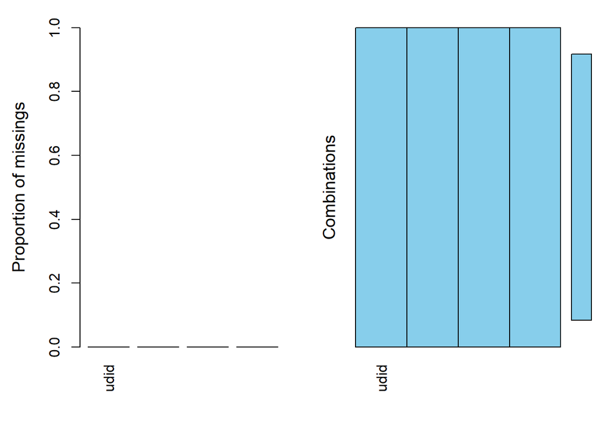

```r
session.miss.val = aggr(session)
```

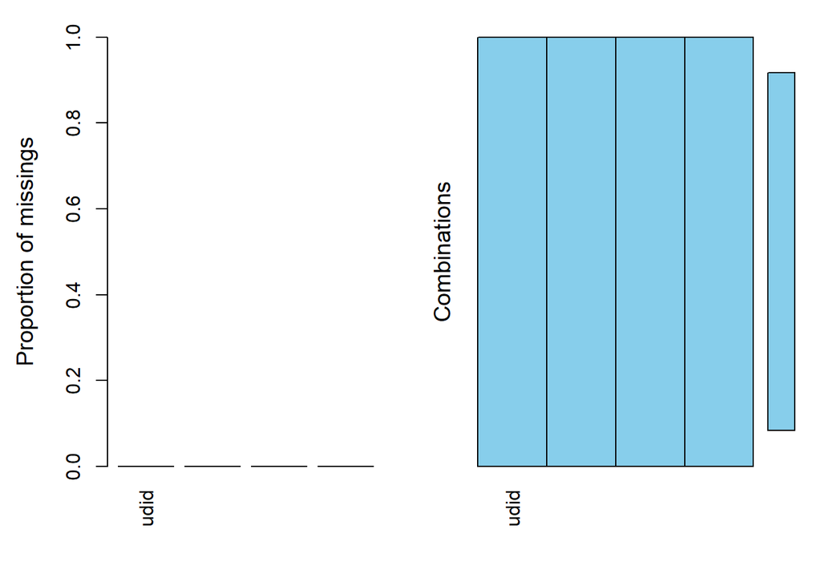

```r
user.miss.val = aggr(user)
```

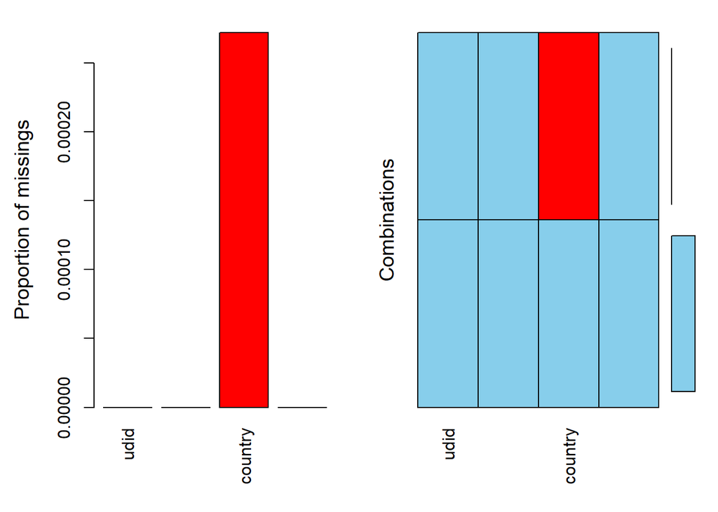

```r
summary(user.miss.val)
```

```
##
##  Missings per variable:
##      Variable Count
##          udid     0
##  install_date     0
##       country    16
##   device_type     0
##
##  Missings in combinations of variables:
##  Combinations Count     Percent
##       0:0:0:0 58826 99.97280854
##       0:0:1:0    16  0.02719146
```

## 4. Exploratory

```r
# Finding the the frequency of device
sort(table(user$device_type), decreasing = T)
```

```
##
## iPhone7 iPhone6   iPad4   iPad2   iPad3 iPhone5 iPhone4   iPad5   iPod5
##   14442   11109    8576    6678    5740    5419    1799    1671    1593
## iPhone3   iPod4 iPhone2
##    1319     408      88
```

```r
length(unique(user$udid)) # 58842 users regiestered
```

```
## [1] 58842
```

```r
length(unique(session$udid)) # 58831 users played the game
```

```
## [1] 58831
```

```r
length(setdiff(session$udid,user$udid)) # 6 users are not in exist User table played  the game
```

```
## [1] 6
```

```r
length(setdiff(user$udid,session$udid)) # 17 users are in User table never played the game after installation
```

```
## [1] 17
```

```r
length(setdiff(IAP$udid, user$udid )) # all user who are listed In App purchase exist in User table
```

```
## [1] 0
```

```r
length(setdiff( user$udid, IAP$udid)) # 56656 users never  purchase
```

```
## [1] 56656
```

```r
length(intersect( user$udid, IAP$udid)) # 2186 users performed in app purchase
```

```
## [1] 2186
```

```r
paste(round(2186/58842*100,2), " percent registered users performed in app purchase")
```

```
## [1] "3.72  percent registered users performed in app purchase"
```

```r
# 6 months aggregation of each paid-user:
total.IAP.by.paiduser =  IAP[,lapply(.SD, sum), by = udid, .SDcols = c("daily_iap_rev", "purchases_made")][order(-daily_iap_rev)]

# biggest spender within 6 months period:
total.IAP.by.paiduser[daily_iap_rev == max(total.IAP.by.paiduser$daily_iap_rev)]
```

```
##                                udid daily_iap_rev purchases_made
## 1: eb0d666878be4e2ab27e82f27f6562be       19645.5            287
```

```r
# most frequent spender within 6 months period:
total.IAP.by.paiduser[purchases_made == max(total.IAP.by.paiduser$purchases_made)]
```

```
##                                udid daily_iap_rev purchases_made
## 1: 4f52b32c78604cf6bc3fa2c52f5448c5        6128.5            494
```

```r
# highest average spender within 6 months period:
avg.IAP.by.paiduser =  IAP[,lapply(.SD, mean), by = udid , .SDcols = c("daily_iap_rev", "purchases_made") ]
avg.IAP.by.paiduser[daily_iap_rev == max(avg.IAP.by.paiduser$daily_iap_rev)]
```

```
##                                udid daily_iap_rev purchases_made
## 1: 20a9272c32354572aa9d97cb6df5e021         234.5             21
```

```r
IAP[udid == "20a9272c32354572aa9d97cb6df5e021"]
```

```
##                                udid transaction_date daily_iap_rev
## 1: 20a9272c32354572aa9d97cb6df5e021       2015-06-19         234.5
##    purchases_made
## 1:             21
```

```r
# average app purchase per transaction event doesnt really tell anything, because a user may perform a large purchase once in his lifetime and  skewing the distribution
```

## 5. 2nd stage Data Cleaning and Building Model

In this stage, I joined User table and IAP table, the reason is because I want to substract the purchase date with the registration date, which would give me days since registration date. Which means there are 7 types of day1 ( since the registration date varies from 2015-06-01 to 2015-06-07). Once I have “days since registration date”“, I can aggregate the purchase amount by that day and figure out how much money spent on day 1,2,3,4,…, 191 since initial registration date. I ploted the Purchase frequency per week to see if how the frequency of purchase progress along the week I ploted average revenue per day since registration day, and the area under the curve is LTV of 6 months I decided to use the cumulative sum of average revenue perday, because of the ease of fitting cumulative plot with logarithmic function, therefore I calculated the cumulative sum and my LTV model defined as:

### LTV(days) = intercept + a(log(days)) + b(days)^2 + c(days)

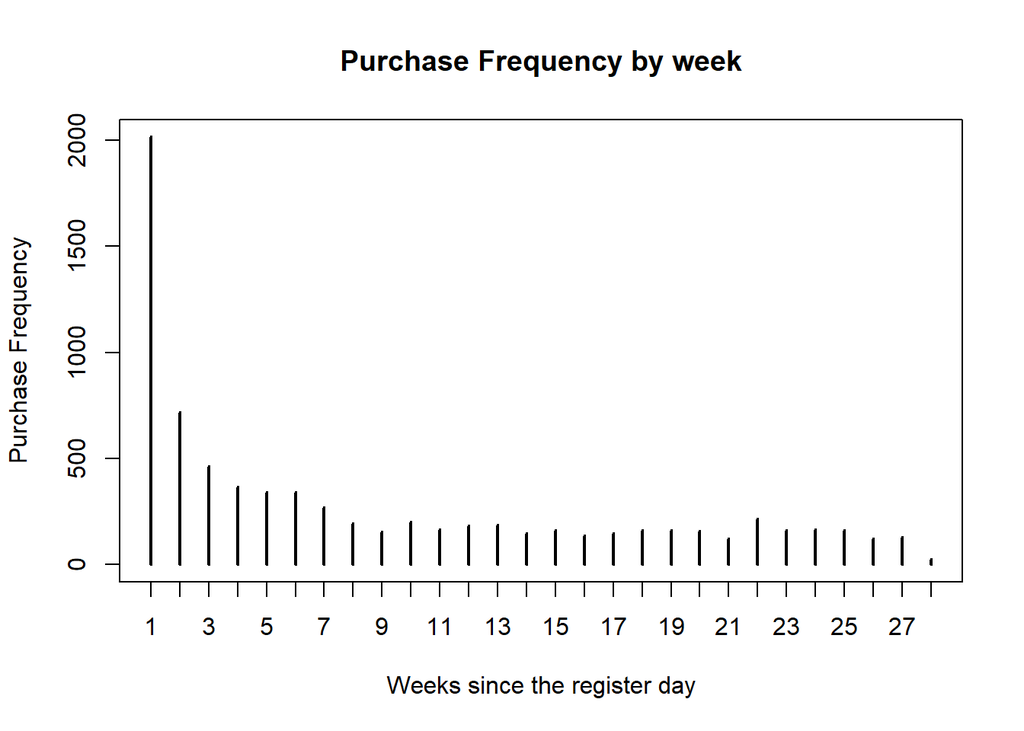

```r
# data wrangling
# Inner join IAP table and User table
user.IAP = merge(user, IAP, by = "udid", all = FALSE)
user.IAP[,days_since_day1 := as.numeric( transaction_date - install_date + 1)][, week_since_week1:= floor((days_since_day1/7) + 1) ]
setkeyv(user.IAP, c("udid", "days_since_day1"))
plot(table(user.IAP$week_since_week1), xlab = "Weeks since the register day", ylab = "Purchase Frequency", main = "Purchase Frequency by week")
```

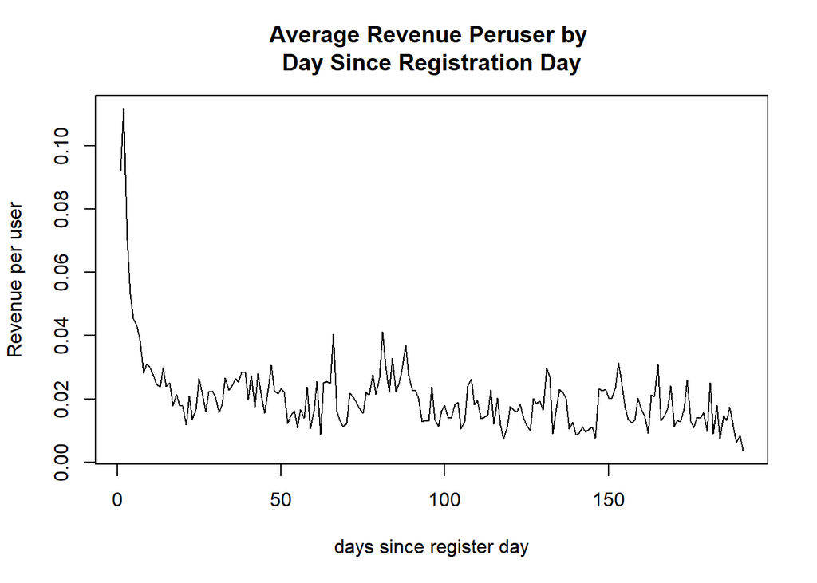

```r
# Revenue by day
aggregated.daily.revenue = user.IAP[,lapply(.SD, sum),by = days_since_day1, .SDcols = "daily_iap_rev"][order(days_since_day1)]
plot(y = (aggregated.daily.revenue$daily_iap_rev)/length(unique(user$udid)),
     x = aggregated.daily.revenue$days_since_day1,
     type = "l",
     xlab = "days since register day",
     ylab = "Revenue per user",
     main = "Average Revenue Peruser by \nDay Since Registration Day")
```

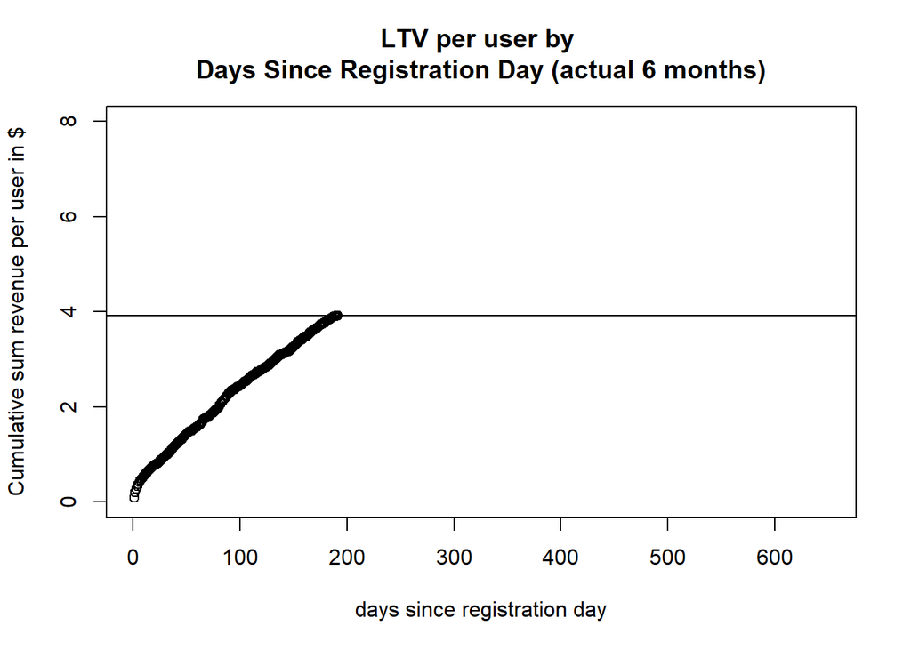

```r
# adding cumulative sum revenue column
aggregated.daily.revenue[,cumsum_rev_peruser := cumsum(daily_iap_rev)/length(unique(user$udid))]

# plotting the CumSum plot based on given data (6 months timeframe)
plot(y = aggregated.daily.revenue$cumsum_rev_peruser,
     x = aggregated.daily.revenue$days_since_day1,
     type = "p",
     xlab = "days since registration day",
     xlim = c(1,650),
     ylim = c(0, 8),
     ylab = "Cumulative sum revenue per user in $",
     main = "LTV per user by \nDays Since Registration Day (actual 6 months)")
abline(max( aggregated.daily.revenue$cumsum_rev_peruser),0)
```

```r
lm_model = lm(cumsum_rev_peruser ~ log(days_since_day1) + poly(days_since_day1,2) , data = aggregated.daily.revenue)
summary(lm_model)
```

```
##
## Call:
## lm(formula = cumsum_rev_peruser ~ log(days_since_day1) + poly(days_since_day1,
##     2), data = aggregated.daily.revenue)
##
## Residuals:
##       Min        1Q    Median        3Q       Max
## -0.090557 -0.019324 -0.001213  0.019009  0.071379
##
## Coefficients:
##                            Estimate Std. Error t value Pr(>|t|)
## (Intercept)                2.034999   0.033632  60.507  < 2e-16 ***
## log(days_since_day1)       0.054118   0.007859   6.886 8.47e-11 ***
## poly(days_since_day1, 2)1 13.958553   0.096060 145.311  < 2e-16 ***
## poly(days_since_day1, 2)2 -0.703937   0.047734 -14.747  < 2e-16 ***
## ---
## Signif. codes:  0 '***' 0.001 '**' 0.01 '*' 0.05 '.' 0.1 ' ' 1
##
## Residual standard error: 0.02909 on 187 degrees of freedom
## Multiple R-squared:  0.9993, Adjusted R-squared:  0.9992
## F-statistic: 8.424e+04 on 3 and 187 DF,  p-value: < 2.2e-16
```

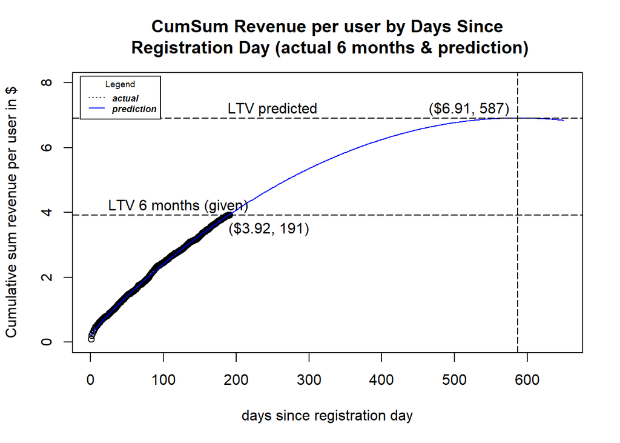

```r
# LTV(days) =  intercept + alog(days) + b(days)^2 + c(days)

plot(y = aggregated.daily.revenue$cumsum_rev_peruser,
     x = aggregated.daily.revenue$days_since_day1,
     pch = 1,
     xlab = "days since registration day",
     xlim = c(1,650),
     ylim = c(0, 8),
     ylab = "Cumulative sum revenue per user in $",
     main = "CumSum Revenue per user by Days Since\n Registration Day (actual 6 months & prediction)")
abline(max( aggregated.daily.revenue$cumsum_rev_peruser),0, lty = 5)

lines(predict(lm_model, data.frame(days_since_day1 = c(1:650))), col = "blue")
abline(max(predict(lm_model, data.frame(days_since_day1 = c(1:650)))),0, lty = 5)
abline(v = which.max (predict(lm_model, data.frame(days_since_day1 = c(1:650)))), lty = 5)
legend(-14, 8.2, legend=c("actual", "prediction"),
       col=c("black", "blue"), lty=c(3,1), cex=0.6,
       title="Legend", text.font=4)

text(245, 3.5, "($3.92, 191)")
text(520, 7.2, "($6.91, 587)")
text(120, 4.2, "LTV 6 months (given)")
text(250, 7.2, "LTV predicted")
```

## 6. Thoughts about Session table

#### The main reason why I didn’t consider a session table in my approach is due to relatively shorter timerange in this table. As inspection in section 2, it only has information until August 31st (3 months), whereas IAP table up to 6 months. However, I have inspected to see if there are correlation between the frequency of plays and total revenue at a given day. Based on 3 months timeframe, I can see there are quite strong correlation between

#### 1. frequency plays and daily Revenue (0.78 correlation coefficient)

#### 2. frequency plays and frequency purchase (0.92 correlation coefficient)

#### Potentially, We can probably analyze and come up with formula that generalized the relation between these 3 variables

```r
# inner join User table and Session table
user.session = merge(user, session, by = "udid", all = FALSE)
user.session[,days_since_day1 := as.numeric( session_date - install_date)][, week_since_week1:= floor(days_since_day1/7) ]

freq.plays.perday = user.session[,.N, by = days_since_day1][order(days_since_day1)]
user.IAP.first3months = user.IAP[transaction_date <=  "2015-08-31" ,lapply(.SD, sum),by = days_since_day1, .SDcols =  c("daily_iap_rev","purchases_made")][order(days_since_day1)]

freqPlays.vs.Rev = data.table(freq.plays.perday = freq.plays.perday$N, revenue=user.IAP.first3months$daily_iap_rev   )
cor(freqPlays.vs.Rev)
```

```
##                   freq.plays.perday   revenue
## freq.plays.perday         1.0000000 0.7800455
## revenue                   0.7800455 1.0000000
```

```r
freqPlays.vs.freqPurchase = data.table(freq.plays.perday = freq.plays.perday$N, freqPurchase = user.IAP.first3months$purchases_made   )
cor(freqPlays.vs.freqPurchase)
```

```
##                   freq.plays.perday freqPurchase
## freq.plays.perday         1.0000000    0.9169166
## freqPurchase              0.9169166    1.0000000
```

## 7. Answer to questions

#### What is LTV (in $) of users in this game? What would you project LTV of these users to be if they continued to play the game beyond the observation period?

#### Answer : 6 months LTV (191 days) = $3.92, Predicted LTV (587 days until steady state) = $6.91

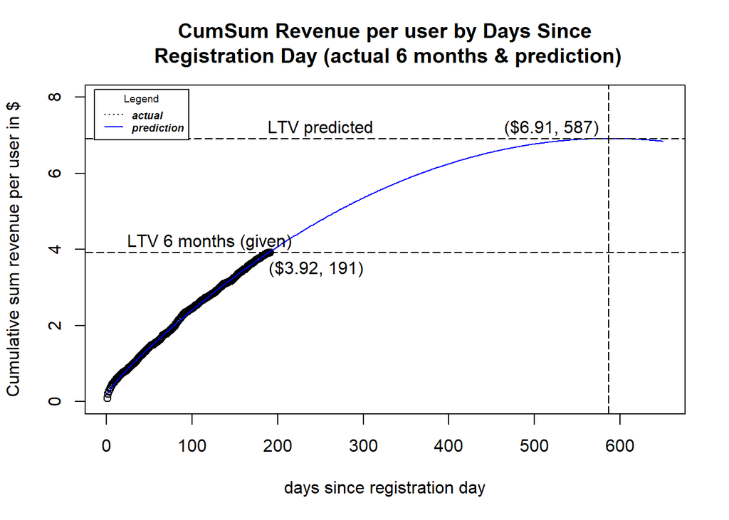

```r
plot(y = aggregated.daily.revenue$cumsum_rev_peruser,
     x = aggregated.daily.revenue$days_since_day1,
     pch = 1,
     xlab = "days since registration day",
     xlim = c(1,650),
     ylim = c(0, 8),
     ylab = "Cumulative sum revenue per user in $",
     main = "CumSum Revenue per user by Days Since\n Registration Day (actual 6 months & prediction)")
abline(max( aggregated.daily.revenue$cumsum_rev_peruser),0, lty = 5)

lines(predict(lm_model, data.frame(days_since_day1 = c(1:650))), col = "blue")
abline(max(predict(lm_model, data.frame(days_since_day1 = c(1:650)))),0, lty = 5)
abline(v = which.max (predict(lm_model, data.frame(days_since_day1 = c(1:650)))), lty = 5)
legend(-14, 8.2, legend=c("actual", "prediction"),
       col=c("black", "blue"), lty=c(3,1), cex=0.6,
       title="Legend", text.font=4)

text(245, 3.5, "($3.92, 191)")
text(520, 7.2, "($6.91, 587)")
text(120, 4.2, "LTV 6 months (given)")
text(250, 7.2, "LTV predicted")
```

#### What are the key assumptions that you are making? What are the weaknesses of these assumptions?

#### Answer :

#### 1. No interesting update in the game that can hype up the slowing down purchase activity (weakness : no upward trend along LTV, only decay)

#### 2. The LTV curve represented by quadratic - logarithmic curve(weakness : the LTV estimated to be decay in logarithmic manner)

#### 3. LTV is univariate function, which means its only depends over time (weakness: it actually depends on much more variables such as: update features, in game events, holiday/non-holiday season, players in-game activity)

#### Why might it be important to have an estimate of a user’s LTV?

#### Answer :

#### Because it allows the manager to have clear and important metric about the game, and decide what direction next:

#### 1. if the LTV is way too low : the manager can decide to just ditch the game and start creating a new and better game

#### 2. if the LTV is acceptable (not too low) : the manager can decide to put more effort improving the game

#### 3. if the LTV is good : the manager can decide to maintain the good performance, while systematially adding new features to improve the LTV

#### How might the LTV of new users change as the game spends more time in the market?

#### Answer :

#### It depends, if there is no interesting update for the game, the LTV of new user would be most likely the same as the existing user or even lower. The reason is because word of mouth between friends. The existing users may start get bored and complaining regarding the lack of update in the game, and eventually they will tell their friends who are about to start playing the game(or just started). In contrast, if the game is periodically updated to fix existing bug and gameplay improvement, the LTV of new user will increase.

#### What additional data might you want to in order improve your estimates? How would you use it?

#### Answer:

#### 1. I have started notice the begining of obvious decay at the begining of month 6th, I believe by having 3 more months of IAP table will improve my model significantly ( by using simpler model)

#### 2. The duration of each session. As my previous inspection showed there are strong correlation between session activities vs Purchase activities, I strongly believe that there are strong correlation between duration of each session and Purchase activities, which eventually affects LTV. If I have this information, I would compare the plot of cumsum revenue (LTV) and cumsum session duration by each day. Then find the conversion rate between playing time and purchase activities, or even incorporate this feature in to my least square model.

#### Would you want to estimate this model for different groups of users rather than using all user data together for your estimate? If so, which groups of users would you want to model separately?

#### Answer:

#### Yes, I would probably calculate the LTV of paid-user ( since only 3.72 % of registered users actually spent their money). Also I would like to see the LTV group based on country and device type. Therefore whenever a new user installed the game (where we tracked his geographic location and device type), we will have some sort of estimate how much LTV this person is.

## 8. Crossvalidation of the model (5-Fold)

#### After the phone interview with Wenjun on Thursday, August 10th. I learned there might be a potential overfitting of the model. One way to check the over fitting is to perform 5 fold cross-validation.

[output not shown]

And after performing the analysis, I saw a bit of RMSE improvement when I tried a simpler model by reducing the polynomial from 2nd degree into 1st degree  
Before : we calculated the cumulative sum and my LTV model defined as:

### LTV(days) = intercept + a(log(days)) + b(days)^2 + c(days)

Now :

### LTV(days) = intercept + a(log(days)) + b(days)

By changing the 2nd degree polynomial into 1st degree, the RMSE average reduced from 0.5456885 into 0.5434066 Finally, here’s the result of my 5-fold cross validation based on my simpler equation (1st degree polynomial):

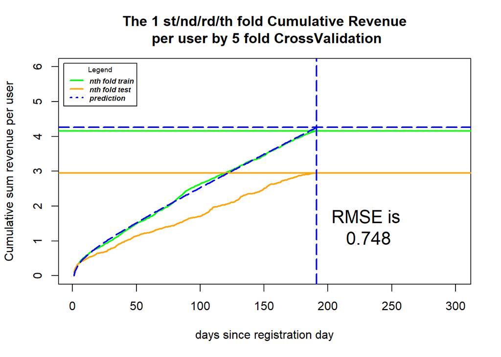

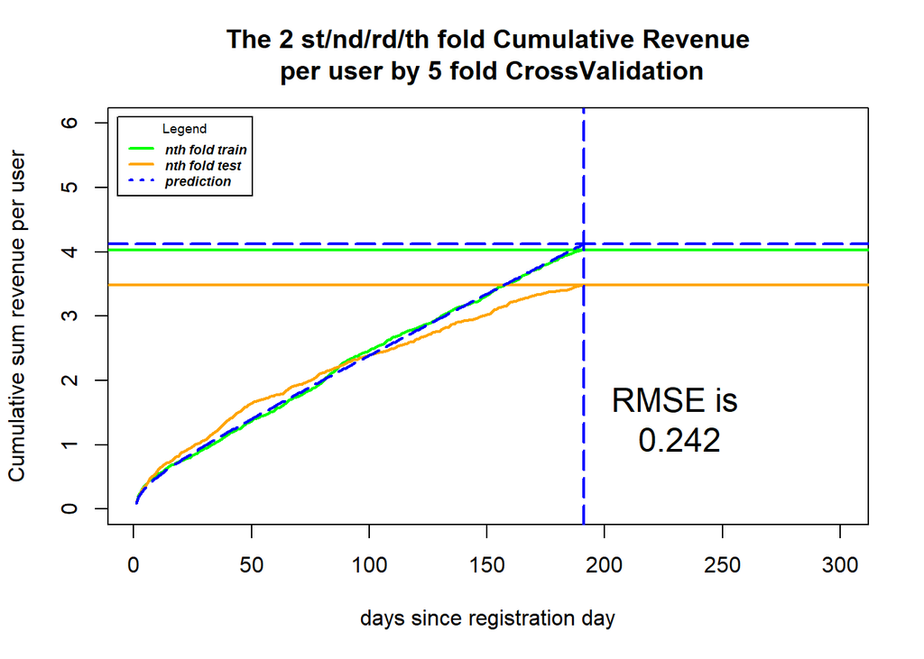

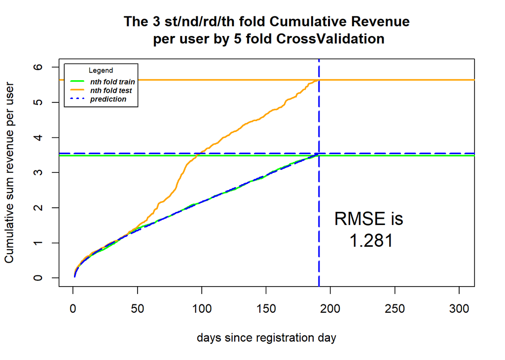

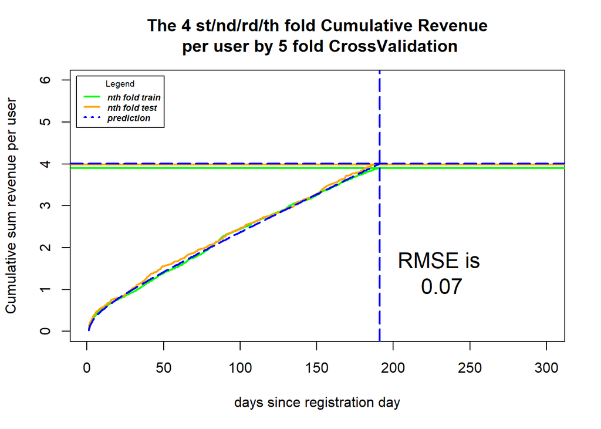

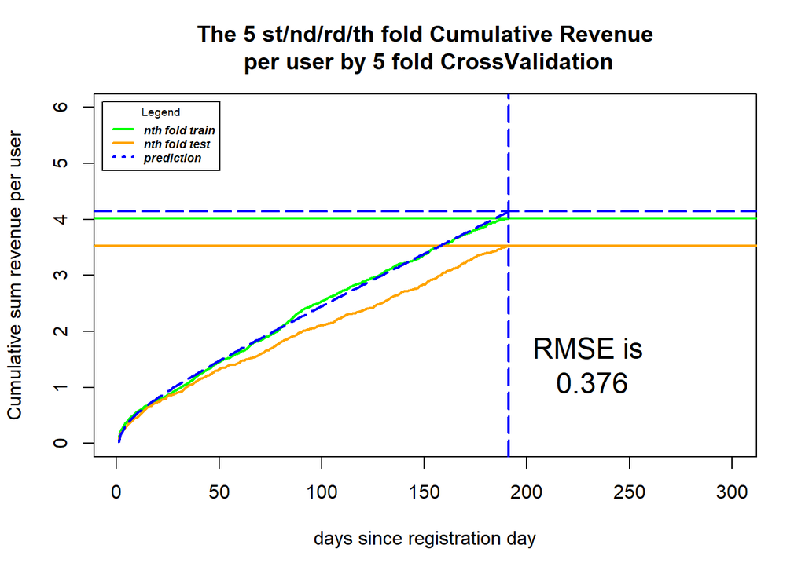

```r
# performing stratified sampling
user.who.paid = unique(IAP$udid)
# we dont need to sample user who do not paid, because the impact weight of each of them is the same (zero impact to revenue)
user.who.not.paid = unique(user$udid)[!unique(user$udid) %in% unique(IAP$udid)]

set.seed(1)
paid.fold = createFolds(seq(1, length(user.who.paid)), k = 5)

RMSE = vector()
for(i in seq(1:5) ){
  user.IAP.fold.n.test = user.IAP[udid %in% user.who.paid[paid.fold[[i]]]]
  user.IAP.fold.n.train = user.IAP[udid %in% user.who.paid[-paid.fold[[i]]]]

  # aggregating by day
  aggregated.daily.revenue.fold.n.test = user.IAP.fold.n.test[,lapply(.SD, sum),by = days_since_day1, .SDcols = "daily_iap_rev"][order(days_since_day1)]
  aggregated.daily.revenue.fold.n.train = user.IAP.fold.n.train[,lapply(.SD, sum),by = days_since_day1, .SDcols = "daily_iap_rev"][order(days_since_day1)]

  # finding average revenue per user
  aggregated.daily.revenue.fold.n.test[,cumsum_rev_peruser := cumsum(daily_iap_rev)/(length(user.who.not.paid)*(1/5) + length(unique(user.IAP.fold.n.test$udid)))]
  aggregated.daily.revenue.fold.n.train[,cumsum_rev_peruser := cumsum(daily_iap_rev)/(length(user.who.not.paid)*(4/5) + length(unique(user.IAP.fold.n.train$udid)))]

  plot(y = aggregated.daily.revenue.fold.n.train$cumsum_rev_peruser,
       x = aggregated.daily.revenue.fold.n.train$days_since_day1,
       type = "l", col = "green", lwd = 2,
       xlab = "days since registration day",
       xlim = c(1,300),
       ylim = c(0, 6),
       ylab = "Cumulative sum revenue per user",
       main = paste("The", i ,"st/nd/rd/th fold Cumulative Revenue\n per user by 5 fold CrossValidation"))
  abline(max( aggregated.daily.revenue.fold.n.train$cumsum_rev_peruser),0, col = "green", lwd = 2)
  lines(y = aggregated.daily.revenue.fold.n.test$cumsum_rev_peruser,
        x = aggregated.daily.revenue.fold.n.test$days_since_day1,
        type = "l", col = "orange", lwd = 2)
  abline(max( aggregated.daily.revenue.fold.n.test$cumsum_rev_peruser),0, col = "orange", lwd = 2)
  lm_model = lm(cumsum_rev_peruser ~ log(days_since_day1) + poly(days_since_day1,1) , data = aggregated.daily.revenue.fold.n.train)
  lines(predict(lm_model, data.frame(days_since_day1 = c(1:191))), lty = 5,col = "blue", lwd = 2 )
  abline(max(predict(lm_model, data.frame(days_since_day1 = c(1:191)))),0, lty = 5, lwd = 2, col = "blue")
  abline(v = which.max (predict(lm_model, data.frame(days_since_day1 = c(1:191)))), lty = 5, lwd = 2, col = "blue")
  legend(-7, 6.1, legend=c("nth fold train","nth fold test", "prediction"),
         col=c("green","orange",  "blue"), lty=c(1,1,3), cex=0.6, lwd = c(2,2,2),
         title="Legend", text.font=4)
  RMSE[i] = sqrt(mean((predict(lm_model, data.frame(days_since_day1 = c(1:length(aggregated.daily.revenue.fold.n.test$cumsum_rev_peruser)))) -
                         (aggregated.daily.revenue.fold.n.test$cumsum_rev_peruser))^2))
  text(230, y = 1.4, labels = paste("RMSE is\n", round(RMSE[i],3)), lwd = 2, cex = 1.5)
  if(i == 1){ plot.1st.k = recordPlot()}
  if(i == 2){ plot.2nd.k = recordPlot()}
  if(i == 3){ plot.3rd.k = recordPlot()}
  if(i == 4){ plot.4th.k = recordPlot()}
  if(i == 5){ plot.5th.k = recordPlot()}
}
```

```r
# RMSE of each fold:
RMSE
```

```
## [1] 0.74849857 0.24153096 1.28119452 0.07014734 0.37566160
```

```r
paste("After performing 5-fold cross validation, the average RMSE is ",round(mean(RMSE),4))
```

```
## [1] "After performing 5-fold cross validation, the average RMSE is  0.5434"
```

### Conclusion:

#### After performing the 5 fold cross validation, I have learned that my model is indeed somewhat overfits the training data, with the average RMSE of $0.5434.In addition, I would like to pointed out that the number of paid users are relatively much smaller than non paid user.Also, even among the paid users, the distribution of spending is not evenly distributed, which means some users spent very small amount of money,while oter users spent extremely large amount of money. Thus, when I performed 5 fold sampling, some sample fold contains these big spender while other folds containst small spender( such as my 1st and 3rd fold according to the grapg), thus it will affect the LTV calculation of each fold.

### Afterwards, this is a fun challenge and I would like to thank you for this opportunity. I have learned a lot in this short period of time about data analyst role in gaming industry